# Heroes & Generals

#### Background

I decided to use data from a video game that I play. In the game, you earn game money in each match that you play. I decided to use a simple linear regression test to see if there is a correlation between money made and time spent in a match. Does the amount of time spent in a match mean that you will make more money?

## Questions and Hypotheses

$$H_0: \beta_1 = 0$$

$$H_a: \beta_1 \neq 0$$
$$\alpha = .05$$

## Analysis

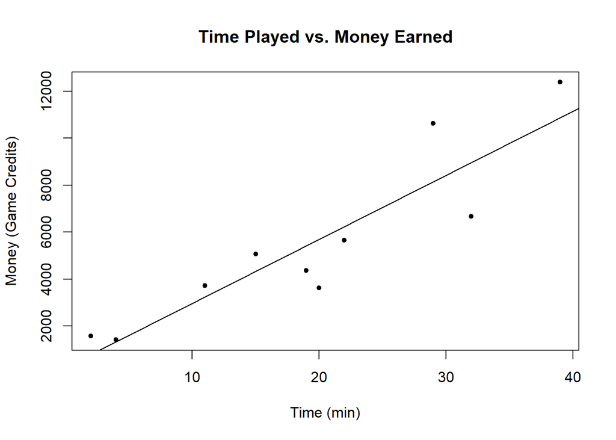

```r
plot(Money ~ Time, data=Heroes, pch=20, xlab="Time (min)", ylab="Money (Game Credits)", main="Time Played vs. Money Earned")

heroes.lm <- lm(Money ~ Time, data=Heroes)
abline(heroes.lm)
```

There does appear to be evidence of a relationship. Assuming the relationship is linear, the following the test will reveal the equation of the fitted line shown in the plot above.

```r
pander(summary(heroes.lm))
```

|  | Estimate | Std. Error | t value | Pr(>\|t\|) |
| --- | --- | --- | --- | --- |
| **(Intercept)** | 258.5 | 1010 | 0.2559 | 0.8045 |
| **Time** | 272.1 | 45.18 | 6.023 | 0.0003153 |

Fitting linear model: Money ~ Time

| Observations | Residual Std. Error | $R^2$ | Adjusted $R^2$ |
| --- | --- | --- | --- |
| 10 | 1612 | 0.8193 | 0.7967 |

Equation: Y = 258.5 + 272.1 X

According to our hypotheses, this equation shows that the slope is significant. (p < .001) The relationship is meaningful.

## Appropriateness Check & Interpretation

If the model is appropriate, then we estimate that by each minute played, we will earn 272.1 game credits. At 0 minutes played, we still earn about 258.5 game credits.

A check on the appropriateness of the model:

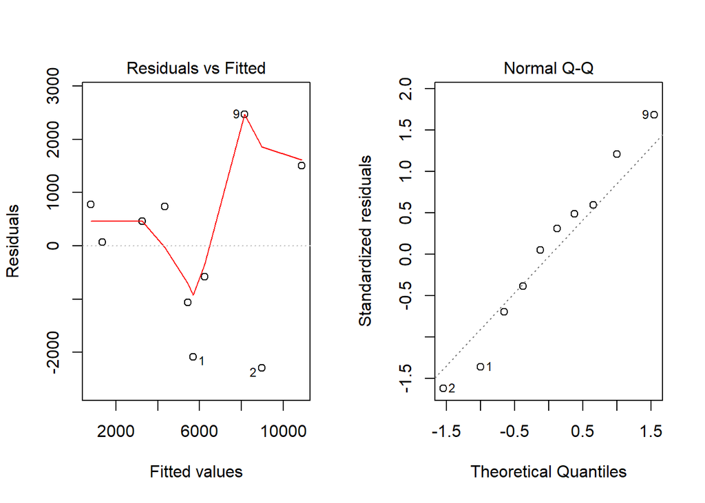

```r
par(mfrow=c(1,2))
plot(heroes.lm, which=1:2)
```

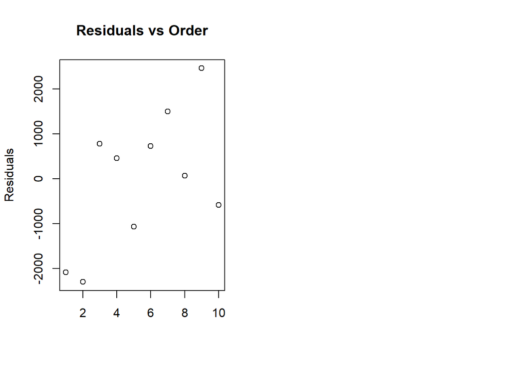

```r
plot(heroes.lm$residuals, main="Residuals vs Order", xlab="",
     ylab="Residuals")
```

It does appear the there is a linear relation, however it does appear to lack constant variance. The Q-Q plot does appear to be slightly normal but might be heavy-tailed. The Residuals vs Order plot shows no trend which indicates that the observations are independent.

In an attempt to correct the potential difficulty with linearity, we create some new graphs with transformations.

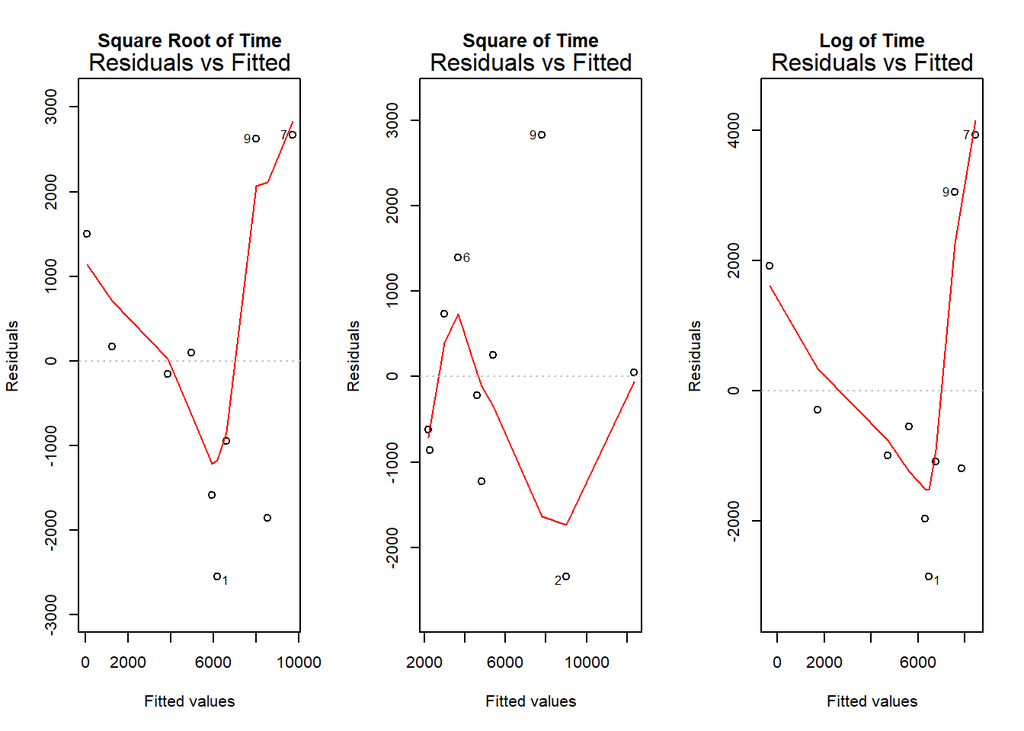

```r
par(mfrow=c(1,3))

Heroes.lm.t1 <- lm(Money ~ sqrt(Time), data=Heroes)
plot(Heroes.lm.t1, which=1, main="Square Root of Time")

Heroes.lm.t2 <- lm(Money ~ I(Time^2), data=Heroes)
plot(Heroes.lm.t2, which=1, main="Square of Time")

Heroes.lm.t3 <- lm(Money ~ log(Time), data=Heroes)
plot(Heroes.lm.t3, which=1, main="Log of Time")
```

Unfortunately, these new graphs do not seem to improve anything so we stick with the original regression.

## Conclusion

There seems to be a linear relationship between time played and money earned. However, some assumptions were not met and this might be due to lack of a large sample size. Another factor that might come into play is individual game performance. You earn more money if you play better so we can keep that in mind when analyzing this data.